# 8.3 The Regression Equation

## Objectives

- Create, analyze, and interpret statistical graphs including histograms, dot plots, stem-and-leaf plots, box plots, and scatter plots.
- Analyze and interpret bivariate data using scatter plots, correlation, and linear regression analysis to determine what would be the prediction for a certain value.
- Analyze an application in the disciplines business, social sciences, psychology, life sciences, health science, and education, and utilize the correct statistical processes to arrive at a solution.

## The Regression Equation

Data rarely fit a straight line exactly. Usually, you must be satisfied with rough predictions. Typically, you have a set of data whose scatter plot appears to **"fit"** a straight line. This is called a **Line of Best Fit** or **Least-Squares Line**.

We can use R to find the coefficients of the line of best fit using the function:

```
lm(y~x)
```

Here, `y~x` means the list of values in `y` depends on the list of values in `x`. The function `lm(y~x)` returns the coefficients of the **l**inear **m**odel that best fits the data.

For example, imagine we have the following data:

| x | y |
| --- | --- |
| 5 | 6 |
| 2 | 4 |
| 4 | 2 |
| 5 | 7 |
| 11 | 13 |
| 0 | -2 |
| 8 | 12 |
| 5 | 8 |

We can use R to find the coefficients of the line of best fit.

```r
x = c(5, 2, 4, 5, 11, 0, 8, 5)
y = c(6, 4, 2, 7, 13, -2, 12, 8)

lm(y~x)
```

```
Call:
lm(formula = y ~ x)

Coefficients:
(Intercept)            x
     -0.625        1.375
```

These give us the $y$-value of the $y$-intercept, $a = -0.625$, and the slope, $b = 1.375$. So the line of best fit for the data is

$$ y = -0.625 + 1.375x $$

We can graph this line *after* graphing the scatterplot using the function `abline`:

```
abline(a, b)
```

Here `a` is the $a$ coefficient and `b` is the $b$ coefficient in the linear equation.

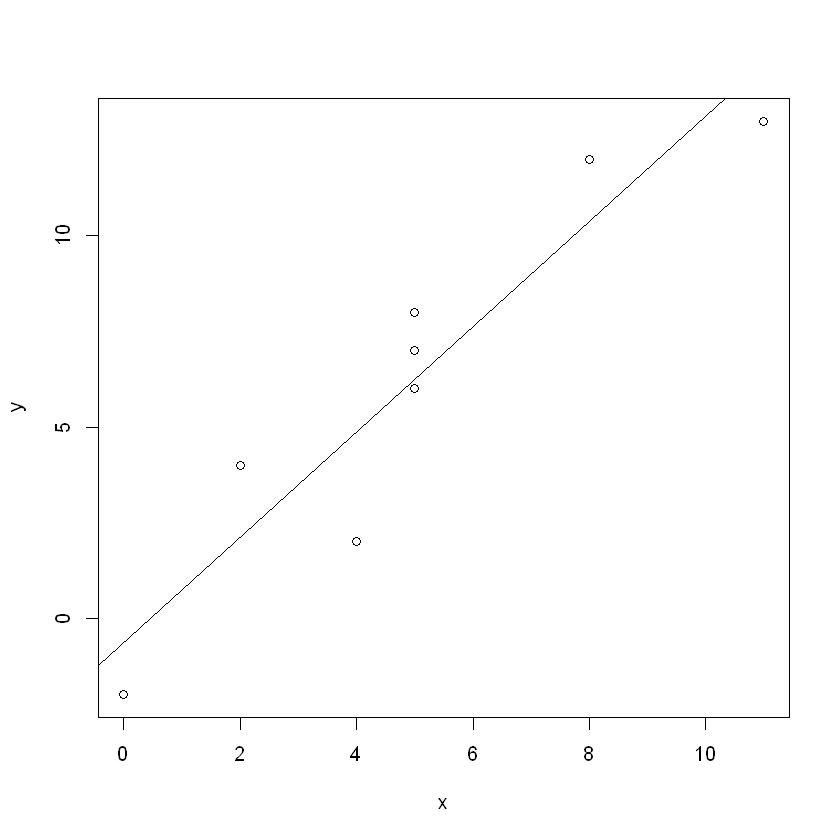

```r
# Graph the scatter plot
plot(x, y)

# Plot the line
abline(a = -0.625, b = 1.375)
```

The line graphed is the best fit for the data points. We can use the equation of the best fit line to predict the $y$-value that would correlate to an $x$-value.

For example, we might want to predict what $y$ would be if $x = 6.5$. We can best predict the $y$-value by plugging $x = 6.5$ into the equation of the best fit line:

$$ y = -0.625 + 1.375x = -0.625 + 1.375(6.5) = 8.3125. $$

So if $x = 6.5$, we predict that $y = 8.3125$.

### Example 3.1

A random sample of 11 statistics students produced the following data, where $x$ is the third exam score out of 80, and $y$ is the final exam score out of 200.

[output not shown]

1. Find the best fit line for the data.
2. Graph the scatter plot of the data together with the best fit line.
3. Predict a student's final exam score if their third exam score is 73.

#### Solution

##### Part 1

We will use R to find the coefficients of the line of best fit.

```r
x = c(65, 67, 71, 71, 66, 75, 67, 70, 71, 69, 69)
y = c(175, 133, 185, 163, 125, 198, 153, 163, 159, 151, 159)

lm(y~x)
```

```
Call:
lm(formula = y ~ x)

Coefficients:
(Intercept)            x
   -176.301        4.866
```

The coefficients of the best fit line are $a = -176.301$ and $b = 4.866$. So the best fit line is

$$ y= -176.301 + 4.866x. $$

##### Part 2

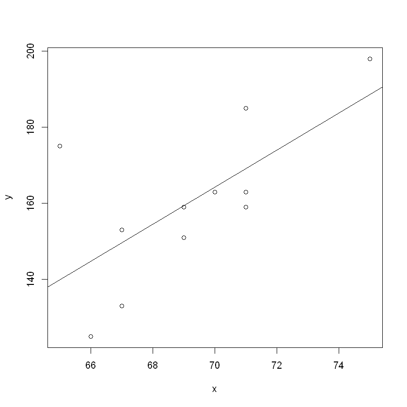

```r
# Graph of the scatter plot
plot(x, y)

# Plot of the best fit line
abline(a = -176.301, b = 4.866)
```

##### Step 3

If the third exam score is 73, we can predict the final exam score by plugging in $x = 73$ into the equation for the best fit line:

$$ y = -176.301 + 4.866x = -176.301 + 4.866(73) = 178.917. $$

So if a student scores 73 points on the third exam, we predict that their final exam score would be about 178.917 points.

### Example 3.2

[video not shown]

**License:** This work is licensed under a [Creative Commons Attribution 4.0 International](https://creativecommons.org/licenses/by/4.0/) license.

**Author:** Taylor Baldwin, Mt. San Jacinto College

**Adapted From:** *Introductory Statistics*, by Barbara Illowsky and Susan Dean. Access for free at [https://openstax.org/books/introductory-statistics/pages/1-introduction](https://openstax.org/books/introductory-statistics/pages/1-introduction).